# Praktikum Rechnernetze

Protokoll zu Versuch 3 (Router-Betriebssystem Cisco IOS) von Gruppe 1

Jakob Waibel

Daniel Hiller

Elia Wüstner

Felicitas Pojtinger

2021-10-19

## 1.1 Einführung

### 1.1.1 Mitwirken

Diese Materialien basieren auf [Professor Kiefers “Praktikum Rechnernetze”-Vorlesung der HdM Stuttgart](https://www.hdm-stuttgart.de/vorlesung_detail?vorlid=5212254).

**Sie haben einen Fehler gefunden oder haben einen Verbesserungsvorschlag?** Bitte eröffnen Sie ein Issue auf GitHub (github.com/pojntfx/uni-netpractice-notes):

QR-Code zum Quelltext auf GitHub

Wenn ihnen die Materialien gefallen, würden wir uns über einen GitHub-Stern sehr freuen.

### 1.1.2 Lizenz

Dieses Dokument und der enthaltene Quelltext ist freie Kultur bzw. freie Software.

Badge der AGPL-3.0-Lizenz

Uni Network Practice Notes (c) 2021 Jakob Waibel, Daniel Hiller, Elia Wüstner, Felicitas Pojtinger

SPDX-License-Identifier: AGPL-3.0

## 1.2 Konfiguration

Anders als in der Anleitung beschrieben, haben wir den Versuch mit Ubuntu durchgeführt. Daher im Folgenden eine kleine Anleitung, wie man sich unter Ubuntu mit dem Router verbinden kann.

Zuerst muss man die Anwendung `screen` installieren.

```bash
$ sudo apt install screen
```

Bevor man den Router nun einsteckt, kann man mit Hilfe von `dmesg` feststellen, welche Gerätebezeichnung der Router hat.

```bash
$ sudo dmesg | grep -i tty
```

Steckt man das Gerät nun ein, sollte man eine Meldung sehen, in welchem eine Device-Bezeichnung zu finden ist. In unserem Fall `ttyUSB0`.

Abschließend muss man sich nur noch mit der Cisco-Konsole verbinden. Dies lässt sich mit folgendem Kommando erreichen.

```bash
$ sudo screen /dev/ttyUSB0
```

Nun sollte eine Verbindung zur Cisco-Konsole bestehen.

### 1.2.1 Konfiguration des Routers, so dass er mittels ping oder telnet von ihrem Rechner erreichbar ist

Um den Router auf die Default-Werte zurückzusetzen, verwenden wir `write erase`. Zur Sicherheit Laden wir den Router neu mit `reload` neu.

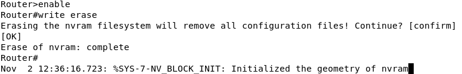

Entfernen aller besthenden Konfigurationsdateien

```bash
Router> enable
Router# write erase
```

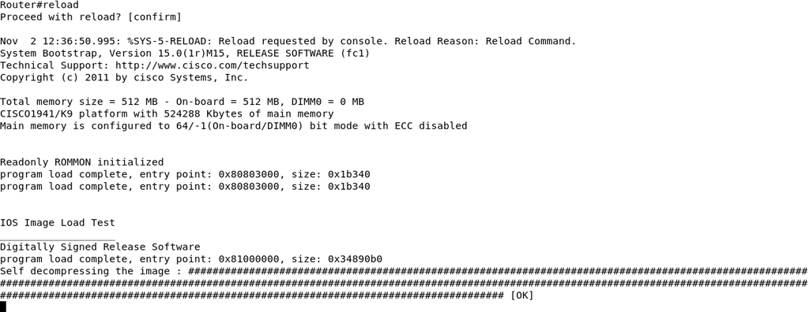

Reload des Routers

```bash
Router# reload
```

Erst wechseln wir mit `enable` in den “Privileged Exec-Mode”, worüber wir anschließend mit `configure terminal` in “Configuration Exec-Mode” gelangen können.

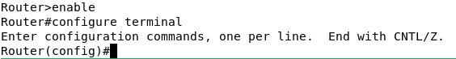

Wechsel in den Configure Terminal-Mode

```bash
Router> enable
Router# configure terminal
```

Den Hostname vergeben wir wie folgt `hostname cisco-gruppe1`.

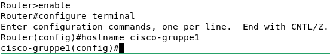

Vergeben eines Hostnamens

```bash
Router(configure)# hostname cisco-gruppe1
```

Bevor wir nun eine IP-Adresse vergeben können, müssen wir in den Interface-Konfigurations-Modus wechseln. Dies können wir im Config-Exec-Mode mit dem Command `interface GigabitEthernet 0/0` erreichen.

Um für `line con 0` kein Passwort zu vergeben, lassen wir den Passwort-Parameter im Kommando weg. Dies sorgt jedoch dafür, dass der Login verwährt wurde, wie im folgenden Scrreenshot zu sehen ist.

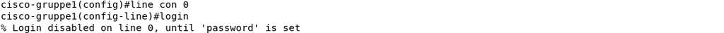

Login line con 0

```bash
cisco-gruppe1(configure)# line con 0
```

Um für `line vty 0 4` das Passwort zu vergeben und uns einzuloggen, können wir folgende Kommandos verwenden.

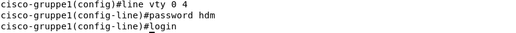

Passwortvergabe von line vty 0 4

```bash
cisco-gruppe1(config)# line vty 0 4
cisco-gruppe1(config-line)# password hdm
cisco-gruppe1(config-line)# login
```

Die Liste, in welcher alle Interfaces mit IP, etc. aufgelistet wird, kann durch `show ip interface brief` erzeugt werden.

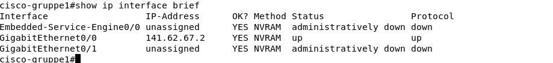

Einsehen aller Interfaces

```bash
cisco-gruppe1# show ip interface brief
```

Um die Konfigurationsdatei einzusehen, können wird `show running-config` verwenden.

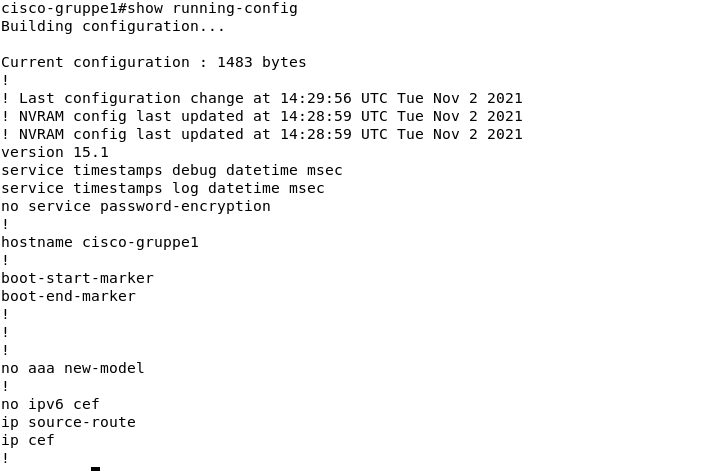

Einsehen der Konfigurationsdateien

```bash
cisco-gruppe1# show running-config
```

Die statisch und dynamischen Routen, können wird mit `show ip route` einsehen.

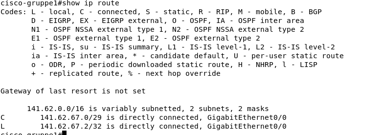

Einsehen der Routen

```bash
cisco-gruppe1# show ip route
```

Informationen zur Version erhalten wir mit `show version`.

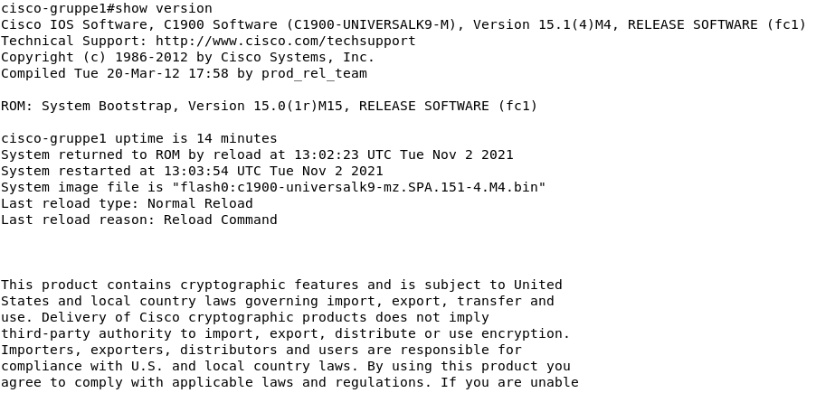

Einsehen der Versionsinformationen

```bash
cisco-gruppe1# show version
```

Nun kann unser Router über `ping` erreicht werden.

## 1.3 Internet-Verbindung unter Einsatz von NAT

### 1.3.1 Konfigurieren Sie ihren Router unter Einsatz von NAT so, dass von einem angeschlossenen PC aus eine Internet verbindung moeglich ist.

Konfiguration `interface GigabitEthernet 0/1`

Interface `GigabitEthernet 0/1` ist in unserer Konfiguration das LAN-Interface

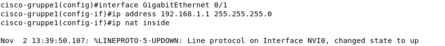

Konfiguration interface GigabitEthernet 0/1

Konfiguration `interface GigabitEthernet 0/0`

Interface `GigabitEthernet 0/0` ist in unserer Konfiguration das WAN-Interface

Anfangs haben wir die falsche IP `141.62.67.2` gesetzt. Diese haben wir im Nachhinein korrigiert.

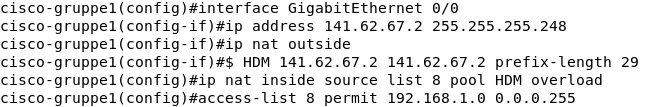

Erste, Fehlerbehaftete Konfiguration

Mit `clear ip nat translation *` können die falschen Konfigurationen rückgängig gemacht werden.

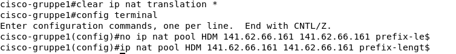

Konfiguration interface GigabitEthernet 0/0

Nun muss noch sichergestellt werden, dass wirklich alle interfaces den Status `up` besitzen. Andernfalls können diese mit `no shutdown` in der jeweiligen Interface-Konfiguration aktiviert werden.

Interfaces mit `show ip interface brief` anzeigen und deren Status abfragen.

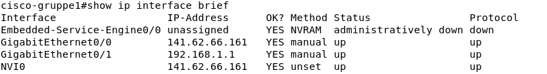

Interfaces anzeigen

Danach kann am Router im `config` mode mit `ip route 0.0.0.0 0.0.0.0 141.62.66.250` die Route zum Router festgelegt werden und die Verbindung zum Internet sollte hergestellt sein.

Bevor der Lokale Computer über unseren Router eine Internetverbindung aufbauen kann, muss auch dieser konfiguriert werden.

Zuerst entfernen wir die alte IP von unserem Netzwerkinterface `enp0s31f6`.

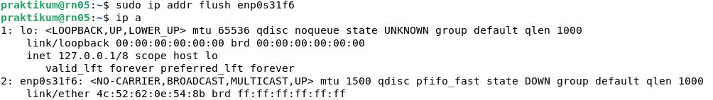

IP entfernen

Danach fügen wir unsere neu bestimmte IP-Adresse zum Netzwerk-Interface hinzu.

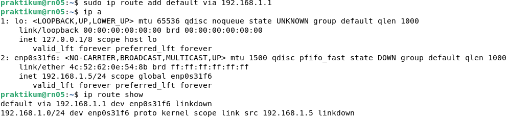

Hinzufügen der neuen IP

Testen der Internetverbindung unseres Lokalen Computers mit einem ping zu `8.8.8.8` (Googles Public DNS-Server). Dafür kann der Command `ping 8.8.8.8` verwendet werden.

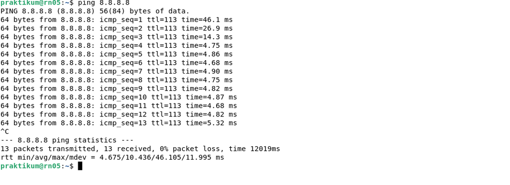

Ping an den Google-DNS-Server

### 1.3.2 Erläutern Sie in der Ausarbeitung die Bedeutung der einzelnen Zeilen der Konfiguration

```bash
interface GigabitEthernet 0/1
ip address 192.168.1.1 255.255.255.0
ip nat inside

interface GigabitEthernet 0/0
ip address 141.6266.161 255.255.255.0
ip nat outside
ip nat pool HDM 141.62.66.161 151.62.66.161 prefix-length 24
ip nat inside source list 8 HDM overload
access-list 8 permit 192.168.1.0 0.0.0.255
```

**`interface GigabitEthernet 0/1`**

In den Interface-Konfigurations-Modus des Interfaces `GigabitEthernet 0/1` wechseln, um dieses zu konfigurieren. Dieses Interface ist in unserem Versuch das LAN-Interface.

**`ip address 192.168.1.1 255.255.255.0`**

Dem Router, in dem momentan konfigurierbaren Interface `GigabitEthernet 0/1` die IP `192.168.1.1` mit der Subnetzmaske `255.255.255.0` zuweisen.

**`ip nat inside`**

Verbindet das interface `GigabitEthernet 0/1` mit dem inneren Netzwerk, welches von NAT betroffen ist.

**`interface GigabitEthernet 0/0`**

Wechselt in den Interface-Konfigurations-Modus des Interfaces `GigabitEthernet 0/0`, um dieses zu konfigurieren. Dieses Interface ist in unserem Versuch das WAN-Interface.

**`ip address 141.62.66.161 255.255.255.0`**

Mit diesem Command wird dem Router, in dem momentan konfigurierbaren Interface `GigabitEthernet 0/0`, die IP-Addresse `141.62.66.161` mit der Subnetzmaske `255.255.255.0` zugewiesen.

**`ip nat outside`**

Verbindet das Interface `GigabitEthernet 0/0` mit dem außenstehenden Netzwerk.

**`ip nat pool HDM 141.62.66.161 141.62.66.161 prefix-length 24`**

Definiert einen NAT-Pool mit der Adress-Range von `141.62.66.161` bis `141.62.66.161`, also genau diese Adresse. Zusätzlich ist noch der Netzwerk-Präfix angegeben, der in unserem Beispiel 24 Bit lang ist.

**`ip nat inside source list 8 HDM overload`**

Verändert die Source-IP der Pakete, die von innen nach aussen geleitet werden. Üebersetzt die Destination-IP der Pakete, die von außen nach innen geleitet werden.

**`access-list 8 permit 192.168.1.0 0.0.0.255`**